# Midterm Group Project

```r
# Loading Packages
library(readxl)
library(tidyverse)
# Cleaning the data
food_supply_unclean = read_csv("FAO_foodsupply.csv")
undernourishment_unclean = read_csv("FAO_undern.csv")
covid19 = read_excel("Covid_19.xlsx")
```

```r
# Undernourishment data
udernourishment <- undernourishment_unclean %>%
  filter(Year == "2017-2019")%>%
  drop_na(Value) %>%
  mutate(undernourishment_percent = Value) %>%
  select(Area,undernourishment_percent)
```

```r
# Fao food Supply data
food_supply <- food_supply_unclean %>%
  filter (Element == "Food supply (kcal/capita/day)") %>%
  group_by(Area) %>%
  summarize(mean_food_supply = mean(Value),median_food_supply = median(Value))
```

```r
# ALL FAO DATA
fao_data_set <- inner_join(udernourishment,food_supply, by = "Area")


# JOINING ALL DATA
# changes <2.5 to 2.5

final_data <- inner_join(fao_data_set,covid19, by = "Area") %>%
  mutate(case_fatality_percent = `CASE-FATALITY`*100,
         undernourishment_x = if_else(undernourishment_percent=="<2.5", 2.5, as.numeric(undernourishment_percent)))
```

```
NAs introduced by coercion
```

## Unstratified Analysis:

### Describe your hypothesis. What do you expect to find and why?

We hypothesized that as undernourishment rate increases, the greater the covid fatality rate. This positive relationship between the two variables was expected because as more individuals become more undernourished, they have lesser food supply and nutrition available to them, thereby causing them to have a weaker immune system. A weaker immune system could lessen an individual’s power to fight back infections like covid-19.

### Relatiosnhip between fatality rate and undernourishment rate by the country

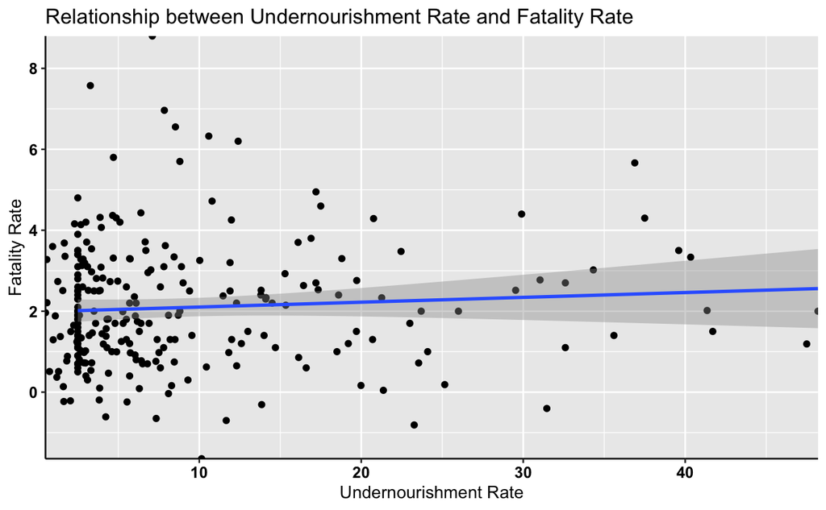

```r
# Ggplot to show relatiosnhip between fatality rate and undernourishment rate by the country
# How do I show countrywise information?

final_data %>%
  remove_missing() %>%
  drop_na() %>%
  ggplot(aes(x = undernourishment_x, y = case_fatality_percent, fill(Area)))+
  geom_point()+
  geom_jitter(height = 2, width = 2)+
  geom_smooth(method = lm)+
  scale_x_continuous(expand = c(0, 0)) + scale_y_continuous(expand = c(0, 0))+
  theme(axis.line = (element_line(colour = "black", size = 0.5, linetype = "solid")))+
  theme(axis.text.x = element_text(face="bold", color="black", size=10)) +
  theme(axis.text.y = element_text(face="bold", color="black", size=10))+
  labs(title= "Relationship between Undernourishment Rate and Fatality Rate" , x = "Undernourishment Rate", y = "Fatality Rate")
```

```r
NA
NA
NA
```

### Performing histogram analysis to check if the variables are normally distributed, and to check for appropriate statistical test.

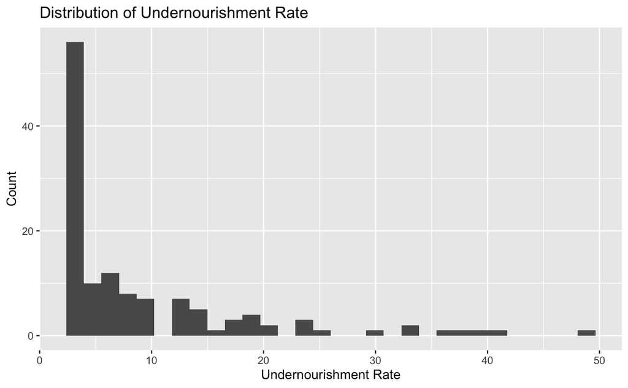

```r
final_data %>%
  remove_missing() %>%
  drop_na() %>%
  ggplot(aes(x = undernourishment_x))+
  geom_histogram()+
  labs(title= "Distribution of Undernourishment Rate" , x = "Undernourishment Rate", y = "Count")
```

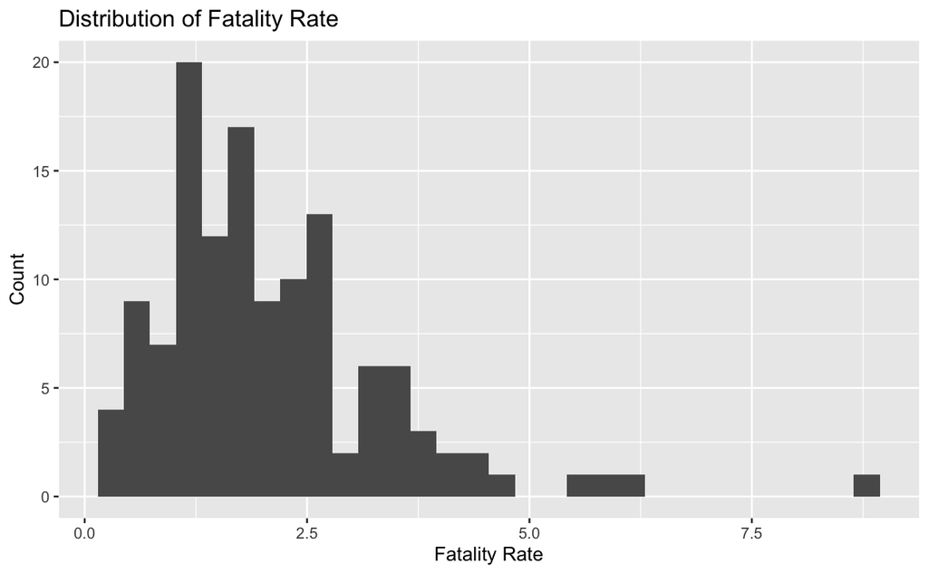

```r
final_data %>%
  remove_missing() %>%
  drop_na() %>%
  ggplot(aes(x = case_fatality_percent))+
  geom_histogram()+
  labs(title= "Distribution of Fatality Rate" , x = "Fatality Rate", y = "Count")
```

We created a histogram to check if our variables of interest were normally distributed. Our analysis showed that both Fatality Rate and Undernourishment Rate were not normally distrbuted and were highly skewed to the right. Because of this we performed a Spearman’s correlation test.

### Statistical test to show relationship between fatality rate and undernourishment rate by the country

```r
#Statistical test to show relationship between mortality rate and undernourishment rate by the country

cor.test(final_data$undernourishment_x,final_data$case_fatality_percent, method = "spearman")
```

```
Cannot compute exact p-value with ties
```

```
    Spearman's rank correlation rho

data:  final_data$undernourishment_x and final_data$case_fatality_percent
S = 313366, p-value = 0.3591
alternative hypothesis: true rho is not equal to 0
sample estimates:
       rho
0.08205048
```